# Computer Simulation STAT2005

## Lecture 1

### Felix Chan, School of Economics and Finance

## Welcome

- Overview of the unit
- Some motivating examples (the fun stuff)
- Some revisions on basic probability and statistics (it has been a long holidays)

## Administrative Overview

- Weekly lecture and workshop (two hours each).
- A case study (quick challenge) sometimes in the middle of the semester.
- A project to be presented by the end of the year.
- The project has three parts: proposal, presentation and final report.
- No examination (yay!)

## Administrative Overview (cont.)

- Group project (no more than 4 people in a group).
- A list of topics will be provided before Week 4.
- Or, you can choose your own BUT you will need approval from teaching staff.
- More information will become available.
- Form group early and think about what you would like to do early.

## Overview (cont.)

- Programming languages R and Python (your choice)
- RStudio/Rmarkdown or Jupyter notebooks (your choice)
- Whenever possible we will cover both R and Python but some workshops will only focus on one or the other.
- Textbook is based on R but the code can be easily translated into Python
- It does mean you will need to have some working knowledge on both.
- RStudio and Anaconda distribtion of Python are recommended.
- If you are really adventurous then try Macport or Brew on OS X and *aptitude* on Debian Linux (or any other package managers).

## Overview (Teaching staff)

Lecturers:

- Felix Chan, School of Economics and Finance
- Aloke Phatak, Department of Mathematics and Statistics
- Ritu Gupa, Department of Mathematics and Statistics
- Artur Lugmayr, Faculty of Humanities

Additional Guest Instructors (Workshop):

- Andrew Rohl
- Artur Lugmayr

## Motivation

- This unit introduces some basic concepts and techniques in Computer Simulations
- why?
- Powerful computers at low cost means computation is now "cheap"
- This allows us to visualise complex systems in specific cases very efficiently.

[figure not shown]

## Example 1 (Logistic map)

Consider the following difference equation:

$$ y_t = Ay_{t-1} \left ( 1- y_{t-1} \right )$$

where $A \in (0,4]$ and $y_t \in [0,1]$ for all $t$.

We usually concern with the behaviour of $y_t$ when $t$ gets large. Two important questions here

1. How does $y_t$ behave with different $A$?
2. How does $y_t$ behave with different initial values ($y_0$)?

```python
def our_diff_eq(N,A,y0):
    """
    Simulate the difference equation :math:' y_t = Ay_{t-1} \left ( 1- y_{t-1} \right )'
    Inputs:
        N: int. The number of observations we wish to generate.
        A: double in (0,4]. The parameter in the difference equation.
        y0: double. The starting point of the difference equation.
    Output:
        y: (N,) numpy array.
    """
    y = np.zeros(N)
    y[0] = y0
    for t in np.arange(1,N):
        y[t] = A*y[t-1]*(1-y[t-1])
    return y
```

```python
%%R
our_diff_eq <- function(N,A,y0) {
    y <- c(y0)
    for (t in 2:N) {
        y[t] <- A*y[t-1]*(1-y[t-1])
    }
    return(y)
}
```

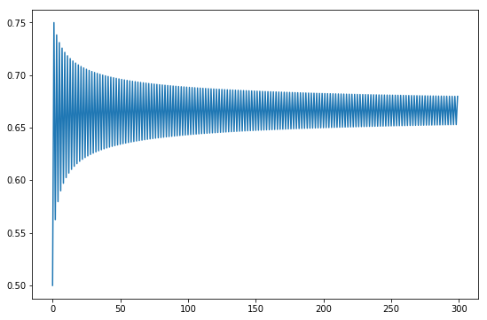

```python
N=300
A = 3
y0 = 0.5
y = our_diff_eq(N,A,y0)
plt.plot(y)
```

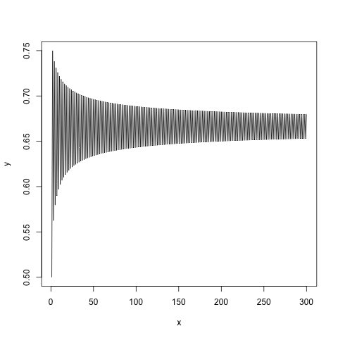

```python
%%R
N <- 300
A <- 3
y0 <- 0.5
y <- our_diff_eq(N,A,y0)
plot(y,type="l", xlab="x")
```

## Example 1 (Logistic Map Cont.)

- Let's see if we can answer the first question. How does $y_t$ behave with different values of $A$?
- One way to do this, is to call *our_diff_eq* function over different values of $A$.
- We can then summarise the outputs as an animation.

```python
ani
```

[video not shown]

## Example 1 (Logistic Map Cont.)

- As $A$ approaches 4, $y_t$ becomes more and more erratic!!
- Note that there is no noise (stochastic component) in the equation. Yet it seems to be generating something that looks "random".
- Take for example, $A=3.99$ with $N=500$

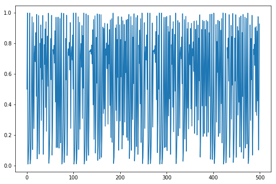

```python
A=3.99
N=500
y = our_diff_eq(N,A,y0)
plt.plot(y)
```

## Example 1. (Logistic Map Cont.)

- Now what about the sensitivity of initial values?
- "Do we always end up in the same place?"
- we can investigate this by repeatedly generating sequences of logistic map with different values of $A$ and different initial values.
- $N$ needs to be sufficietly large or the changes from one element to the next is very very small.

```python
def our_diff_eq_limit(N,A,y0,tol_level=1e-6):
    """
    Simulate the difference equation :math:' y_t = Ay_{t-1} \left ( 1- y_{t-1} \right )'
    Inputs:
        N: int. The maximum number of observations we wish to generate.
        A: double in (0,4]. The parameter in the difference equation.
        y0: double. The starting point of the difference equation.
        tol_level: positive float. Tolerance level.
    Output:
        y: (N,) numpy array.
    """
    y = np.zeros(N)
    y[0] = y0
    t=1
    tol=0
    while (tol==0)&(t<N):
        y[t] = A*y[t-1]*(1-y[t-1])
        if abs(y[t]-y[t-1])< tol_level:
            tol = 1
        else:
            t=t+1
    return y[t-1]
```

```python
N = 5000
y0set = np.arange(0.01,1,0.01)
Aset = np.arange(0.01,4,0.01)
ly = y0set.shape[0]
lA = Aset.shape[0]
bfset = np.zeros(ly*lA)
lAx = np.kron(Aset, np.ones(ly))
for i,A in enumerate(Aset):
    for j,y0 in enumerate(y0set):
        k = i*ly+j
    #    print("working on {0} elements out of {1}".format(k, ly*lA))
        temp = our_diff_eq_limit(N,A,y0)
        bfset[k] = temp
```

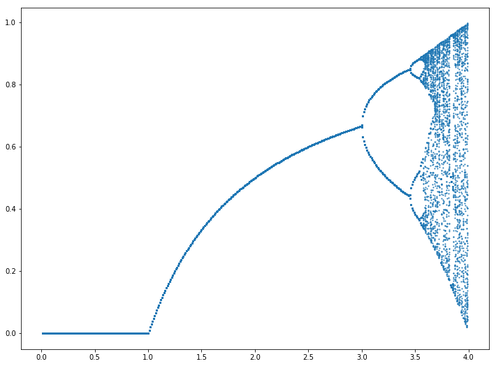

```python
plt.scatter(lAx, bfset, s=1)
```

## Data Visualisation

- So the simulation is helpful.
- However, we can do more!
- All the points were drawn at the same time.
- There may be more information if we can see all the possible values for each $A$ incrementally.
- In other words, let's make an animation!

```python
bf_animb
```

[video not shown]

## Example 2 (GST Redistribution)

- The example above is completely deterministic. There is no stochastic component.
- Simulation techniques are even more helpful in studying stochastic processes.
- Or even just problems involving probabilities. See the Birthday party problem in Workshop.
- A pratical example is the GST redistribution.

## Example 2 (GST Redistribution)

- Federal government collects Good and Services Tax (GST) and redistribute them back to the states by an equalisation formula.
- The idea is to ensure that all states have the same fiscal capacity to provide public goods.
- Australia follows a **Revenue Transfer System** (RTS) which looks a little like this $$ \rho_j (t) = \left ( 1- \frac{Y_j(t)}{L_j(t)} \frac{L(t)}{Y(t)} \right ) \frac{Q(t)}{L(t)} $$

where $\rho_j(t)$ is the net transfer (revenue given to the Federal government substracts the redistribution) given to state $j$ at time $t$, $Y_j(t)$ and $Y(t)$ are the outputs of state $j$ and the total outputs of the country at time $t$, respectively. In other words, $\displaystyle Y(t) = \sum_j Y_j(t)$. $L_j(t)$ and $L(t)$ are the population of state $j$ and the total population of the country. $Q(t)$ is the total expenditure of public goods. An important constraint is that $\displaystyle \sum_j \rho_j(t) = 0$ for all $t$.

## Example 2 (GST Redistribution)

$$ \rho_j (t) = \left ( 1- \frac{Y_j(t)}{L_j(t)} \frac{L(t)}{Y(t)} \right ) \frac{Q(t)}{L(t)} $$

- When $Q(t)$ increases, $\rho_j(t)$ increases.
- If state $j$ outputs per person is growing faster than the country average, then $\rho_j(t)$ decreases.
- Questions: how should state manage economic growth in such a way that it does not loose out on redistribution?
- Two problems here: States "games" against each other. So how should each state "plays" this game? Is there a (Nash) equilibrium?
- State output is uncertain and so is demand of public services. Not knowing the likely value of the net transfer will make budgetting difficult. Both state output and demand of public services can be modelled as stochastic process.
- In order words, we have a stochastic game! Computer Simulation would be helpful as it is unlikely we are able to solve it analytically.
- A project for this unit?

### Limitation

Like everything else, simulation has its own limitations.

- Simulation result is not a "proof".
- Special cases.
- Often insightful but not always reliable when studying asymptotic behaviours.

Consider:

$$ y_t = \phi_1 y_{t-1} + \phi_2 y_{t-1} I(t>t_0) + \varepsilon_t $$

where $I(A)=1$ if $A$ is true, and 0 otherwise.

If $t_0=1000$ and we only simulate a total number of 500 observations then we don't really see what is happening when $T$ gets large.

## Review of Probability and Statistics

- Mostly come from Jones et al. (Ch. 14 and 15) and STAT1001
- Sets
- Probability
- Random variables
- Various distriutions

### Sets

- $\emptyset$ denotes empty set.
- $\Omega$ is often used to denote a set of all possible outcomes, *sample space*.
- An *event* is any subset of $\Omega$.
- $A$\ $B = \{x: x\in A \text{ and } x \not \in B\}$
- $A\cup B = \{x: x\in A \text{ or } x \in B\}$, the union operator.
- $A\cap B = \{x: x \in A \text{ and } x \in B\}$, the intersection operator.
- $\bar{A} = \Omega$\ $A$, the complement of $A$. Sometimes we use $A^c$.

### Probability axioms

- $\Pr (\Omega) = 1$.
- $\Pr (A) > 0$.
- $\Pr \left ( \sum^\infty_{i=1} A_i \right ) = \sum^\infty_{i=1} \Pr (A_i)$ if $A_i$ are disjoint sets, i.e. $A_i \cap A_j =\emptyset$ for $i\neq j$.

### Some Common Probability Rules

From the axioms we should be able to prove the following (quite easily)

- $\Pr (\emptyset) = 0 $.
- $\Pr \left (\bar{A} \right ) = 1 - \Pr (A)$.
- $\Pr (A) < \Pr (B)$ if $A \subset B$.
- $\Pr \left (A \cup B \right ) = \Pr (A) + \Pr (B) - \Pr \left ( A \cap B \right )$.

### Conditional Probability

$$\Pr(A|B) = \frac{\Pr (A \cap B)}{\Pr (B)} $$

- Is knowing $B$ helpful?
- Independent vs. mutually exclusive

### Independent

$$ \begin{align} \Pr (A|B) =& \frac{\Pr (A\cap B)}{\Pr(B)} \\ =& \Pr (A) \\ \Pr (A\cap B) =& \Pr (A) \Pr (B) \end{align} $$

- The second line follows because knowing $B$ does not change the probability of $A$ if they are independent.
- This is consistent with what we already know. The probability of two indepdent events is the product of their probabilities.

### Mutually Exclusive

By definition, if $A$ and $B$ are mutually exclusive then $\Pr (A \cap B) = 0$. This implies $$\Pr (A|B) = 0$$.

- Clearly, if $A$ and $B$ cannot happen together then observing $B$ means $A$ cannot happen!
- $\Pr( X=1 | X=0)=0$

### Law of total probability

Let $A_i$ be mutually exclusive and exhaustive events for $i=1,\ldots, k$, i.e. $\displaystyle \cup^k_{i=1} A_i = \Omega$ and $B$ denotes any other event. $$\begin{align} \Pr (B) =& P \left [ B \cap \left ( \overset{k}{\underset{i=1}{\cup}} A_i \right ) \right ] \\ =& \sum^k_{i=1} \Pr (B \cap A_i ) \\ =& \sum^k_{i=1} \Pr (B|A_i)\Pr(A_i) \end{align} $$

### Random variables

Formal definition is not required but fun to just take a look. There are couple of formulations but we follow Papoulis (1984, p. 88)

$$X:\Omega \rightarrow E$$

and $X^{-1}(B) \in \mathit{F}$ for any $B\subset \tilde{E}$ where $\mathit{F}$ denotes the $\sigma$-algebra i.e. collection of all events.

If $E$ is finite or countably infinite then $X$ is a *discrete* random variable.

If $E$ is uncountably infinite then $X$ is a *continuous* random variable.

Normally $E\subseteq \mathbb{R}$.

- Axiomatic approach to this can be fun but scary (take a course in Measure Theory if this tickles your fancy).
- Intuition is that we are mapping an outcome (or some atrributes of) to a number.
- Probabilties associated with the outcomes will also be associated with the associated numbers.
- Elementary example: coin toss. $\Omega = \{H, T\}$ and define the random variable $X$ such that $X=1$ if $H$ otherwise $X=0$. So $E=\{0,1\}$ and $\Pr (H) = \Pr (X=1) = 0.5$.

### PMF, PDF and CDF

- The distribution of probabilities for a discrete random variable can be mathematically described by its *probability mass function* (PMF).
- The distribution of probabilities for a continuous random variable can be mathematically described by its *probability density function* (PDF). Note that if $f(x)$ is a PDF then $$f(x) \geq 0 \quad \forall x \quad \text{ and } \quad \int^\infty_{-\infty} f(x) dx = 1.$$
- The cumulative distribution function (CDF), $F(x)$, for the random variable $X$ is $\Pr ( X\leq x)$.

### Expectation

Let $X$ be a discrete random variable with a set of possible values $D$ then the *expected value* of $X$ is defined to be $$\mathbb{E} (X) = \underset{x\in D}{\sum} xp(x)$$

where $p(x)$ denotes the PMF. Similarly, let $X$ be a continuous random variable with the support $D$ then the *expected value* of $X$ is defined to be $$\mathbb{E} (X) = \int_D xf(x) dx$$ where $f(x)$ denotes the PDF.

### Interpretation of expected value

Let $X$ be the random variable representing the outcome of rolling a fair dice. This means $p(x)=1/6$ for $x=1,\ldots, 6$. The expected value is therefore $$ \mathbb{E} (X) = \sum^6_{x=1} \frac{x}{6} =3.5. $$ How does one interpret this number?

### Properties of the expectation operator

- $\mathbb{E} (a) = a$ if $a$ is a finite constant.
- It is linear i.e. for any random variables $X$, $Y$, with finite expectations, $\mathbb{E} (aX + bY)=a\mathbb{E} (X) + b \mathbb{E} (Y)$ for any $a,b \in \mathbb{R}$.
- Let $X$ be a discrete random varaible with a set of possible values $D$ and PMF, $p(x)$, then $$ \mathbb{E} \left [ h(X) \right ] = \underset{x\in D}{\sum} h(x)p(x)$$ for any function $h(x)$. Similarly, let $X$ be a continuous random variable with support $D$ and PDF, $f(x)$, then $$ \mathbb{E} \left [ h(X) \right ] = \int_D h(x)f(x)dx.$$

### Variance

Let $h(x) = \left [x-\mathbb{E} (X) \right ]^2$ then $\sigma^2_X = \mathbb{E} \left [ h(x) \right ]$ is called the *variance* of $X$ and $\sigma_X$ is the standard deviation of $X$.

### Higher order moment

The variance is also known as the *second centralised moment* and the definition above extends naturally to higher order. That is, let $h(x) = \left [ X-\mathbb{E} (X) \right ]^n$ then $\mathbb{E} [h(x)]$ is called the $n^{th}$ centralised moment (if exists).

Higher order moments are often associated with other useful properties of the probability distributions, such as, skewness and kurtosis. More about this later (hopefully).

### Joint PMF and PDF

Let $X$ and $Y$ be two discrete random variables, then $p(x,y) = \Pr (X=x, Y=y)$ is called the *joint* probability mass function. Similarly, $f(x,y)$ is the *joint* probability density function if $$ \Pr \left [ (X,Y) \in A \right ] = \underset{A}{\int\int} f(x,y) dxdy.$$

The evaluation of the double integral is often achieved by iteration. First integrate with respect to $x$ then with respect to $y$. This is possible becasue of Fubini's Theorem. It holds almost always for us but there are cases when it doesn't.

### Marginal PMF and PDF

- $p_X(x) = \sum_{y} p(x,y)$ and $f_X (x) = \int_{-\infty}^{\infty} f(x,y) dy$. Mariginal PMF and PDF for $y$ are defined in the same manner.
- If $X$ and $Y$ are independent then $p(x,y) = p_X(x)p_Y(y)$ and similarly, $f(x,y) = f_X(x)f_Y(y)$.

### Expectation (again)

The definition of expected value extends naturally to joint PMF and PDF. Let $X$ and $Y$ be two discrete random variables with the joint PMF, $p(x,y)$. Let $h(x,y)$ denote a bi-variate scalar function then $$ \mathbb{E} \left [ h(X,Y) \right ] = \sum_x \sum_y h(x,y) p(x,y).$$

Similarly, let $X$ and $Y$ be two continuous random variables with the joint PDF, $p(x,y)$, then $$ \mathbb{E} \left [ h(X,Y) \right ] = \int \int h(x,y) f(x,y)dxdy.$$

Recall the claim $\mathbb{E} (aX + bY) = a\mathbb{E} (X) + b \mathbb{E} (Y)$. First we prove the discrete case:

Let $h(x,y) = ax + by$ then $$ \begin{align} \mathbb{E} (aX + bY) =& \sum_x\sum_y (ax+by)p(x,y) \\ =& a\sum_x\sum_y x p(x,y) + b \sum_x\sum_y yp(x,y) \\ =& a\sum_x\sum_y x p(x,y) + b \sum_y\sum_x yp(x,y) \\ =& a\sum_x \left [x\sum_y p(x,y) \right ] + b \sum_y\left [y\sum_x p(x,y)\right ] \\ =& a\sum_xx p_X(x) + b \sum_y yp_Y(y) \\ =& a\mathbb{E} (X) + b \mathbb{E} (Y) \end{align} $$

For the continuous case, we operate under the condition of Fubini's theorem. In other words, the order of integration does not matter. Let $h(x,y) = ax + by$ then $$ \begin{align} \mathbb{E} (aX + bY) =& \int\int (ax+by)f(x,y)dxdy \\ =& a\int\int x f(x,y)dxdy + b \int\int yf(x,y)dxdy \\ =& a\int\int x f(x,y)dydx + b \int\int yf(x,y)dxdy \\ =& a\int \left [x\int f(x,y)dy \right ]dx + b \int\left [y\int f(x,y) dx\right ]dy \\ =& a\int x f_X(x)dx + b \int yf_Y(y)dy \\ =& a\mathbb{E} (X) + b \mathbb{E} (Y) \end{align} $$

### Covariance

Let $X$ and $Y$ be two discrete random variables with PMF, $p(x,y)$. Let $h(x,y) = (x-\mu_x)(y-\mu_y)$ where $\mu_x$ and $\mu_y$ denote $\mathbb{E} (X)$ and $\mathbb{E} (Y)$, respectively, then $\mathbb{E} [ h(X,Y) ]$ is called the covariance of $X$ and $Y$.

Similarly Let $X$ and $Y$ be two continuous random variables with PDF, $f(x,y)$. Let $h(x,y) = (x-\mu_x)(y-\mu_y)$ where $\mu_x$ and $\mu_y$ denote $\mathbb{E} (X)$ and $\mathbb{E} (Y)$, respectively, then $\mathbb{E} [ h(X,Y) ]$ is called the covariance of $X$ and $Y$.

In both cases, $$ \rho_{XY} = \frac{\mathbb{E} [ h(X,Y) ]}{\sigma_X \sigma_Y} $$ is called the correlation of $X$ and $Y$.

### Covariance and correlation

- Both measure **linear** dependence.
- Correlation is scale invariant but covariance is NOT.

Let $Z=kX$ for some $k\in \mathbb{R}$, then $\mu_z = k\mu_x$ and $\sigma_Z = k\sigma_X$ (prove them!). This means $h(Z,Y) = k h(X,Y)$ and therefore $\mathbb{E} [ h(Z,Y) ] = k \mathbb{E} [ h(X,Y) ]$ BUT $$\begin{align} \rho_{ZY} =& \frac{\mathbb{E} [ h(Z,Y) ]}{\sigma_Z \sigma_Y} \\ =&\frac{k\mathbb{E} [ h(X,Y) ]}{k\sigma_X \sigma_Y} \\ =& \frac{\mathbb{E} [ h(X,Y) ]}{\sigma_X \sigma_Y} \\ =& \rho_{XY} \end{align} $$

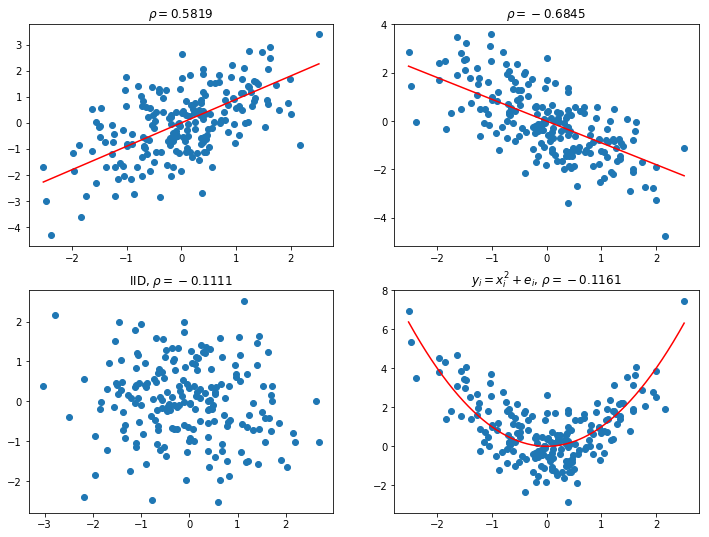

```python
draw_corr()
```

### Discrete Distributions

- Binomial, $X\sim Bin(n,p)$ $$ b(x;n,p) = \begin{pmatrix} n \\ x \end{pmatrix} p^x (1-p)^{n-x}, \qquad x=0,1,2,\ldots, n$$
- Poisson, $X\sim Poi(\lambda)$ $$ p(x; \lambda) = \frac{\exp (-\lambda) \lambda^x}{x!}, \qquad x=0,1,2,\ldots $$
- Negative Binomial, $X\sim NB(r,p)$ $$ nb(x;r,p) = \begin{pmatrix} x-1\\ r-1 \end{pmatrix} p^r (1-p)^{x-r}, \qquad x=r,r+1,r+2,\ldots$$
- Hypergeometric, $X\sim Hyp(n,M,N)$ $$h(x;n,M,N) = \frac{ \begin{pmatrix} M \\ x \end{pmatrix} \begin{pmatrix} N-M \\ n-x \end{pmatrix}}{\begin{pmatrix} N\\ n \end{pmatrix} },$$ $$\max (0, n-N+M) \leq x \leq \min (n,M)$$

### Continuous Distributions

- Uniform, $X\sim U[A,B]$ $$ f(x; A,B) = \frac{1}{B-A}, \qquad A \leq x \leq B $$
- Exponential, $X\sim Exp(\lambda)$ $$ f(x; \lambda) = \lambda \exp (-\lambda x), \qquad x>0$$
- Normal, $X\sim N(\mu, \sigma^2)$ $$ f(x;\mu, \sigma) = \frac{1}{\sigma \sqrt{2\pi}} \exp \left [ -\frac{ (x-\mu)^2}{2\sigma^2} \right ], \qquad x\in \mathbb{R}$$

### Parameters

- The parameters in each distribution control the location, shape and scale of the distribution.
- In general, the more parameters in the distribution, the more "flexible" it is.
- In practice we seldom knows these parameter values and therefore we must estimate them through data.
- We may come back to this later.
- We can, however, examine how these parameters change the shape (and other attributes) of the distributions by using simple simulation.
- Two examples: Binomial and Normal.

```python
def binomial(x,n,p):
    """
    An implementation of the probability mass function for the binomial distribution.
    Inputs:
        x: positive int (including 0) that is less than n.
        n: positive int.
        p: Probability of success.
    Output:
        b(x; n,p)
    """
    if (x>n)|(n==0):
        print('Inappropriate x or n values')
    elif (type(x) != int)|(type(n)!=int):
        print("Both x and n must be integers")
    else:
        return spm.comb(n,x)*np.power(p,x)*np.power(1-p,n-x)
```

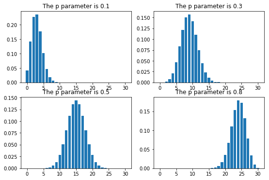

```python
N=30
pset = [0.1,0.3,0.5,0.8]
for i,p in enumerate(pset):
    z = np.array([binomial(x,N,p) for x in range(N+1)])
    plt.subplot(2,2,i+1)
    plt.bar(range(N+1), z)
    plt.title('The p parameter is {0}'.format(p))
```

```python
def normal(x,m,s):
    """
    An implementation of the normal PDF.
    Inputs:
        x: scalar.
        m: scalar. The mean of the normal random variate.
        s: positive scalar. The standard deviation of the normal random variate.
    """

    return np.exp( -np.power(x-m,2)/(2*np.power(s,2)))/(s*np.power(2*np.pi,0.5))
```

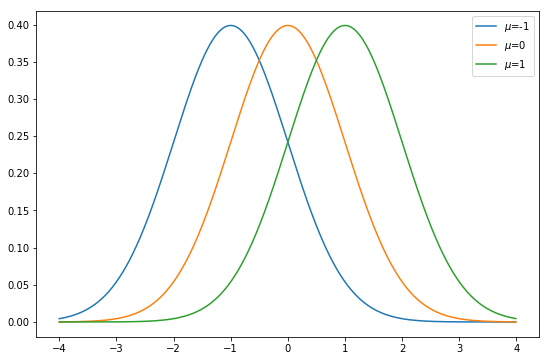

```python
xset = np.arange(-4,4,0.01)
mset = [-1,0,1]
title = []
for i,m in enumerate(mset):
    temp = np.array([normal(x,m,1) for x in xset])
    plt.plot(xset,temp)
    title.append(r'$\mu$={0}'.format(m))
plt.legend(title)
```

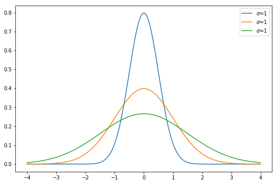

```python
sset = [0.5,1,1.5]
title = []
for i,s in enumerate(sset):
    temp = np.array([normal(x,0,s) for x in xset])
    plt.plot(xset,temp)
    title.append(r'$\sigma$={0}'.format(m))
plt.legend(title)
```

### Conclusion

- Introduction of the unit.
- Some motivations (hopefully convincing).
- Reviews of Probability and Statistics (hopefully redundant).